# 04 - Modeling

### Imports

```r
library(dplyr)
library(ggplot2)
library(caret)
```

```r
train_set <- readRDS("../data/train_set.rds")
head(train_set)
```

|  | Gender | Age | Education.Level | Institution.Type | IT.Student | Location | Load.shedding | Financial.Condition | Internet.Type | Network.Type | Class.Duration | Self.Lms | Device | Adaptivity.Level |
| --- | --- | --- | --- | --- | --- | --- | --- | --- | --- | --- | --- | --- | --- | --- |
| 1 | Boy | 21-25 | University | Non Government | No | Yes | Low | Mid | Wifi | 4G | 3-6 | No | Tab | Moderate |
| 2 | Girl | 21-25 | University | Non Government | No | Yes | High | Mid | Mobile Data | 4G | 1-3 | Yes | Mobile | Moderate |
| 3 | Girl | 16-20 | College | Government | No | Yes | Low | Mid | Wifi | 4G | 1-3 | No | Mobile | Moderate |
| 4 | Girl | 11-15 | School | Non Government | No | Yes | Low | Mid | Mobile Data | 4G | 1-3 | No | Mobile | Moderate |
| 5 | Girl | 16-20 | School | Non Government | No | Yes | Low | Poor | Mobile Data | 3G | 0 | No | Mobile | Low |
| 6 | Boy | 11-15 | School | Non Government | No | Yes | Low | Poor | Mobile Data | 3G | 1-3 | No | Mobile | Low |

```r
test_set <- readRDS("../data/test_set.rds")
head(test_set)
```

|  | Gender | Age | Education.Level | Institution.Type | IT.Student | Location | Load.shedding | Financial.Condition | Internet.Type | Network.Type | Class.Duration | Self.Lms | Device | Adaptivity.Level |
| --- | --- | --- | --- | --- | --- | --- | --- | --- | --- | --- | --- | --- | --- | --- |
| 14 | Girl | 16-20 | College | Non Government | No | No | Low | Mid | Wifi | 4G | 1-3 | No | Mobile | Low |
| 16 | Boy | 11-15 | School | Non Government | No | Yes | High | Poor | Wifi | 4G | 1-3 | No | Mobile | Low |
| 23 | Girl | 16-20 | College | Non Government | No | No | Low | Mid | Mobile Data | 3G | 3-6 | Yes | Mobile | Low |
| 29 | Girl | 1-5 | School | Non Government | No | Yes | Low | Mid | Mobile Data | 4G | 1-3 | No | Mobile | Moderate |
| 35 | Boy | 11-15 | School | Non Government | No | Yes | Low | Poor | Mobile Data | 3G | 1-3 | No | Mobile | Low |
| 51 | Boy | 16-20 | College | Government | No | Yes | Low | Mid | Wifi | 4G | 1-3 | No | Mobile | Low |

```r
train_set_rfe <- readRDS("../data/train_set_rfe.rds")
head(train_set_rfe)
```

|  | Class.Duration | Financial.Condition | Institution.Type | Gender | Self.Lms | Location | Age | Internet.Type | Network.Type | Education.Level | IT.Student | Device | Adaptivity.Level |
| --- | --- | --- | --- | --- | --- | --- | --- | --- | --- | --- | --- | --- | --- |
| 1 | 3-6 | Mid | Non Government | Boy | No | Yes | 21-25 | Wifi | 4G | University | No | Tab | Moderate |
| 2 | 1-3 | Mid | Non Government | Girl | Yes | Yes | 21-25 | Mobile Data | 4G | University | No | Mobile | Moderate |
| 3 | 1-3 | Mid | Government | Girl | No | Yes | 16-20 | Wifi | 4G | College | No | Mobile | Moderate |
| 4 | 1-3 | Mid | Non Government | Girl | No | Yes | 11-15 | Mobile Data | 4G | School | No | Mobile | Moderate |
| 5 | 0 | Poor | Non Government | Girl | No | Yes | 16-20 | Mobile Data | 3G | School | No | Mobile | Low |
| 6 | 1-3 | Poor | Non Government | Boy | No | Yes | 11-15 | Mobile Data | 3G | School | No | Mobile | Low |

```r
test_set_rfe <- readRDS("../data/test_set_rfe.rds")
head(test_set_rfe)
```

|  | Class.Duration | Financial.Condition | Institution.Type | Gender | Self.Lms | Location | Age | Internet.Type | Network.Type | Education.Level | IT.Student | Device | Adaptivity.Level |
| --- | --- | --- | --- | --- | --- | --- | --- | --- | --- | --- | --- | --- | --- |
| 14 | 1-3 | Mid | Non Government | Girl | No | No | 16-20 | Wifi | 4G | College | No | Mobile | Low |
| 16 | 1-3 | Poor | Non Government | Boy | No | Yes | 11-15 | Wifi | 4G | School | No | Mobile | Low |
| 23 | 3-6 | Mid | Non Government | Girl | Yes | No | 16-20 | Mobile Data | 3G | College | No | Mobile | Low |
| 29 | 1-3 | Mid | Non Government | Girl | No | Yes | 1-5 | Mobile Data | 4G | School | No | Mobile | Moderate |
| 35 | 1-3 | Poor | Non Government | Boy | No | Yes | 11-15 | Mobile Data | 3G | School | No | Mobile | Low |
| 51 | 1-3 | Mid | Government | Boy | No | Yes | 16-20 | Wifi | 4G | College | No | Mobile | Low |

### Modeling

Define repeated 10-fold cross validation.

```r
fit_control <- trainControl(
  method = "repeatedcv",
  number = 10,
  repeats = 10
)
```

Define a helper function to train model.

```r
train_model <- function(method = "",
                        data = train_set,
                        tuneGrid = NULL,
                        tuneLength = 3) {
  set.seed(42)

  fit <- train(
    Adaptivity.Level ~ .,
    data = data,
    method = method,
    trControl = fit_control,
    tuneGrid = tuneGrid,
    tuneLength = tuneLength
  )

  print(fit)

  return(fit)
}
```

Define a helper function to evaluate model.

```r
evaluate_model <- function(
    model = NULL,
    alias = "",
    data = test_set,
    family = "") {

  pred <- predict(model, data)

  cm <- confusionMatrix(pred, data$Adaptivity.Level, mode = "prec_recall")
  print(cm)

  return(data.frame(
    Model = alias,
    Family = ifelse(family == "", alias, family),
    Accuracy = round(cm$overall[["Accuracy"]], 3),
    Precision.Low = round(cm$byClass["Class: Low", "Precision"], 3),
    Recall.Low = round(cm$byClass["Class: Low", "Recall"], 3),
    F1.Low = round(cm$byClass["Class: Low", "F1"], 3),
    Precision.Moderate = round(cm$byClass["Class: Moderate", "Precision"], 3),
    Recall.Moderate = round(cm$byClass["Class: Moderate", "Recall"], 3),
    F1.Moderate = round(cm$byClass["Class: Moderate", "F1"], 3),
    Precision.High = round(cm$byClass["Class: High", "Precision"], 3),
    Recall.High = round(cm$byClass["Class: High", "Recall"], 3),
    F1.High = round(cm$byClass["Class: High", "F1"], 3)
  ))
}
```

#### Logistic Regression

##### Train Set

```r
lr_clf <- train_model("glmnet")
```

```
glmnet

964 samples
 13 predictor
  3 classes: 'Low', 'Moderate', 'High'

No pre-processing
Resampling: Cross-Validated (10 fold, repeated 10 times)
Summary of sample sizes: 868, 868, 868, 868, 867, 868, ...
Resampling results across tuning parameters:

  alpha  lambda        Accuracy   Kappa
  0.10   0.0003546083  0.7224023  0.4905860
  0.10   0.0035460831  0.7179446  0.4813492
  0.10   0.0354608311  0.6994781  0.4356542
  0.55   0.0003546083  0.7220909  0.4899170
  0.55   0.0035460831  0.7135911  0.4718133
  0.55   0.0354608311  0.6666065  0.3611243
  1.00   0.0003546083  0.7215711  0.4889117
  1.00   0.0035460831  0.7102749  0.4641123
  1.00   0.0354608311  0.6526020  0.3161986

Accuracy was used to select the optimal model using the largest value.
The final values used for the model were alpha = 0.1 and lambda
 = 0.0003546083.
```

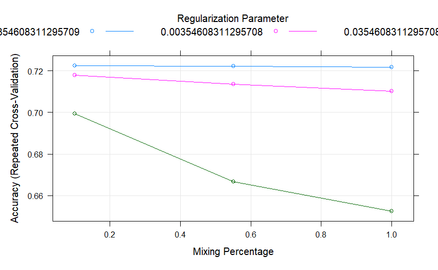

```r
plot(lr_clf)
```

Perform hyperparameter tuning using `tuneLength`.

```r
lr_clf <- train_model("glmnet", tuneLength = 10)
```

```
glmnet

964 samples
 13 predictor
  3 classes: 'Low', 'Moderate', 'High'

No pre-processing
Resampling: Cross-Validated (10 fold, repeated 10 times)
Summary of sample sizes: 868, 868, 868, 868, 867, 868, ...
Resampling results across tuning parameters:

  alpha  lambda        Accuracy   Kappa
  0.1    8.191912e-05  0.7227137  0.491289434
  0.1    1.892438e-04  0.7227137  0.491289434
  0.1    4.371777e-04  0.7224034  0.490594031
  0.1    1.009937e-03  0.7216774  0.489071002
  0.1    2.333086e-03  0.7193965  0.484371651
  0.1    5.389731e-03  0.7161823  0.477312870
  0.1    1.245098e-02  0.7123421  0.468259733
  0.1    2.876337e-02  0.7025870  0.443731527
  0.1    6.644712e-02  0.6893106  0.410190926
  0.1    1.535015e-01  0.6601622  0.337789820
  0.2    8.191912e-05  0.7227137  0.491275958
  0.2    1.892438e-04  0.7227137  0.491289434
  0.2    4.371777e-04  0.7223013  0.490355986
  0.2    1.009937e-03  0.7215732  0.488867727
  0.2    2.333086e-03  0.7187747  0.483124337
  0.2    5.389731e-03  0.7149356  0.474643217
  0.2    1.245098e-02  0.7104779  0.463360826
  0.2    2.876337e-02  0.6968900  0.430657265
  0.2    6.644712e-02  0.6758355  0.380085162
  0.2    1.535015e-01  0.6561190  0.323014306
  0.3    8.191912e-05  0.7228168  0.491478643
  0.3    1.892438e-04  0.7227137  0.491289434
  0.3    4.371777e-04  0.7221972  0.490155556
  0.3    1.009937e-03  0.7209504  0.487564127
  0.3    2.333086e-03  0.7179446  0.481479296
  0.3    5.389731e-03  0.7135932  0.471669455
  0.3    1.245098e-02  0.7079875  0.457082282
  0.3    2.876337e-02  0.6933602  0.422362727
```

[output cut: 61 more lines]

```
  0.9    1.535015e-01  0.6018471  0.190447176
  1.0    8.191912e-05  0.7228157  0.491523106
  1.0    1.892438e-04  0.7222992  0.490391356
  1.0    4.371777e-04  0.7212597  0.488330150
  1.0    1.009937e-03  0.7184590  0.482660307
  1.0    2.333086e-03  0.7130756  0.470671943
  1.0    5.389731e-03  0.7052932  0.452398778
  1.0    1.245098e-02  0.6837124  0.405340744
  1.0    2.876337e-02  0.6507238  0.317134327
  1.0    6.644712e-02  0.6634751  0.333409554
  1.0    1.535015e-01  0.5202459  0.003683884

Accuracy was used to select the optimal model using the largest value.
The final values used for the model were alpha = 0.7 and lambda
 = 8.191912e-05.
```

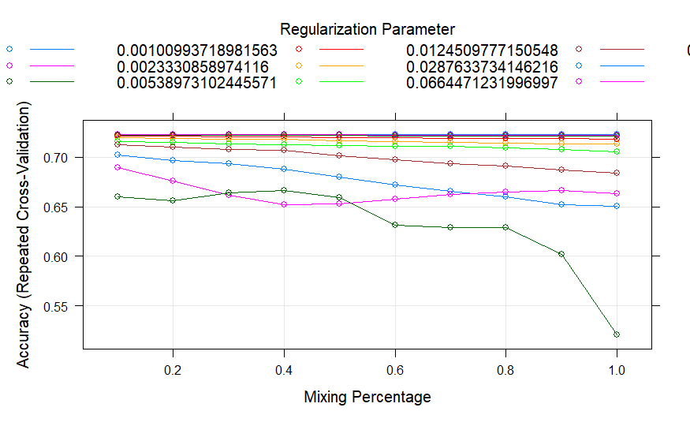

```r
plot(lr_clf)
```

Tuning done.

```r
lr_metrics <- evaluate_model(lr_clf, "LR")
```

```
Confusion Matrix and Statistics

          Reference
Prediction Low Moderate High
  Low       63       28    3
  Moderate  32       90    9
  High       1        7    8

Overall Statistics

               Accuracy : 0.668
                 95% CI : (0.6047, 0.7272)
    No Information Rate : 0.5187
    P-Value [Acc > NIR] : 1.862e-06

                  Kappa : 0.4042

 Mcnemar's Test P-Value : 0.6784

Statistics by Class:

                     Class: Low Class: Moderate Class: High
Precision                0.6702          0.6870     0.50000
Recall                   0.6562          0.7200     0.40000
F1                       0.6632          0.7031     0.44444
Prevalence               0.3983          0.5187     0.08299
Detection Rate           0.2614          0.3734     0.03320
Detection Prevalence     0.3900          0.5436     0.06639
Balanced Accuracy        0.7212          0.6833     0.68190
```

##### Train Set (RFE)

```r
lr_clf_rfe <- train_model("glmnet", train_set_rfe)
```

```
glmnet

964 samples
 12 predictor
  3 classes: 'Low', 'Moderate', 'High'

No pre-processing
Resampling: Cross-Validated (10 fold, repeated 10 times)
Summary of sample sizes: 868, 868, 868, 868, 867, 868, ...
Resampling results across tuning parameters:

  alpha  lambda        Accuracy   Kappa
  0.10   0.0003546083  0.7225075  0.4907407
  0.10   0.0035460831  0.7184665  0.4821219
  0.10   0.0354608311  0.6999957  0.4367096
  0.55   0.0003546083  0.7217784  0.4892426
  0.55   0.0035460831  0.7142118  0.4729358
  0.55   0.0354608311  0.6667107  0.3612768
  1.00   0.0003546083  0.7217794  0.4892207
  1.00   0.0035460831  0.7105842  0.4646580
  1.00   0.0354608311  0.6526020  0.3161986

Accuracy was used to select the optimal model using the largest value.
The final values used for the model were alpha = 0.1 and lambda
 = 0.0003546083.
```

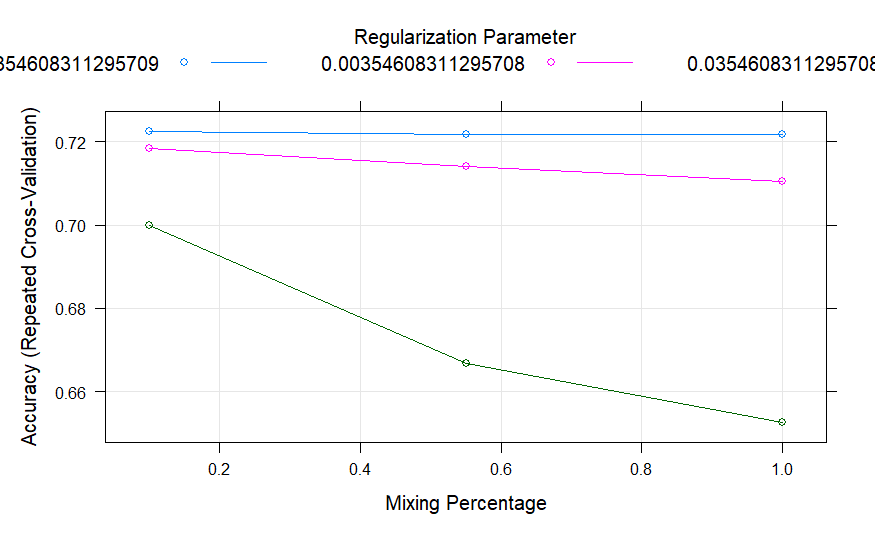

```r
plot(lr_clf_rfe)
```

Perform hyperparameter tuning using `tuneLength`.

```r
lr_clf_rfe <- train_model("glmnet", train_set_rfe, tuneLength = 10)
```

```
glmnet

964 samples
 12 predictor
  3 classes: 'Low', 'Moderate', 'High'

No pre-processing
Resampling: Cross-Validated (10 fold, repeated 10 times)
Summary of sample sizes: 868, 868, 868, 868, 867, 868, ...
Resampling results across tuning parameters:

  alpha  lambda        Accuracy   Kappa
  0.1    8.191912e-05  0.7225075  0.490687256
  0.1    1.892438e-04  0.7225075  0.490687256
  0.1    4.371777e-04  0.7224034  0.490538885
  0.1    1.009937e-03  0.7214701  0.488547870
  0.1    2.333086e-03  0.7196048  0.484635506
  0.1    5.389731e-03  0.7170135  0.478761986
  0.1    1.245098e-02  0.7120361  0.467306283
  0.1    2.876337e-02  0.7035202  0.445636387
  0.1    6.644712e-02  0.6911695  0.413977821
  0.1    1.535015e-01  0.6602652  0.338081338
  0.2    8.191912e-05  0.7225075  0.490687256
  0.2    1.892438e-04  0.7225075  0.490687256
  0.2    4.371777e-04  0.7224034  0.490529086
  0.2    1.009937e-03  0.7211576  0.487879112
  0.2    2.333086e-03  0.7196037  0.484593856
  0.2    5.389731e-03  0.7163885  0.477410725
  0.2    1.245098e-02  0.7110009  0.464396211
  0.2    2.876337e-02  0.6973013  0.431437354
  0.2    6.644712e-02  0.6766656  0.381834819
  0.2    1.535015e-01  0.6561190  0.323014306
  0.3    8.191912e-05  0.7224034  0.490538904
  0.3    1.892438e-04  0.7225075  0.490687256
  0.3    4.371777e-04  0.7220898  0.489865893
  0.3    1.009937e-03  0.7209493  0.487526555
  0.3    2.333086e-03  0.7188789  0.482994669
  0.3    5.389731e-03  0.7147348  0.473786189
  0.3    1.245098e-02  0.7084010  0.457915142
  0.3    2.876337e-02  0.6933591  0.422345919
```

[output cut: 61 more lines]

```
  0.9    1.535015e-01  0.6018471  0.190447176
  1.0    8.191912e-05  0.7225064  0.490732241
  1.0    1.892438e-04  0.7219856  0.489641370
  1.0    4.371777e-04  0.7211576  0.487946643
  1.0    1.009937e-03  0.7182517  0.482082550
  1.0    2.333086e-03  0.7141098  0.472720622
  1.0    5.389731e-03  0.7057066  0.453310789
  1.0    1.245098e-02  0.6834021  0.404745180
  1.0    2.876337e-02  0.6508290  0.317396032
  1.0    6.644712e-02  0.6634751  0.333409554
  1.0    1.535015e-01  0.5202459  0.003683884

Accuracy was used to select the optimal model using the largest value.
The final values used for the model were alpha = 0.1 and lambda
 = 0.0001892438.
```

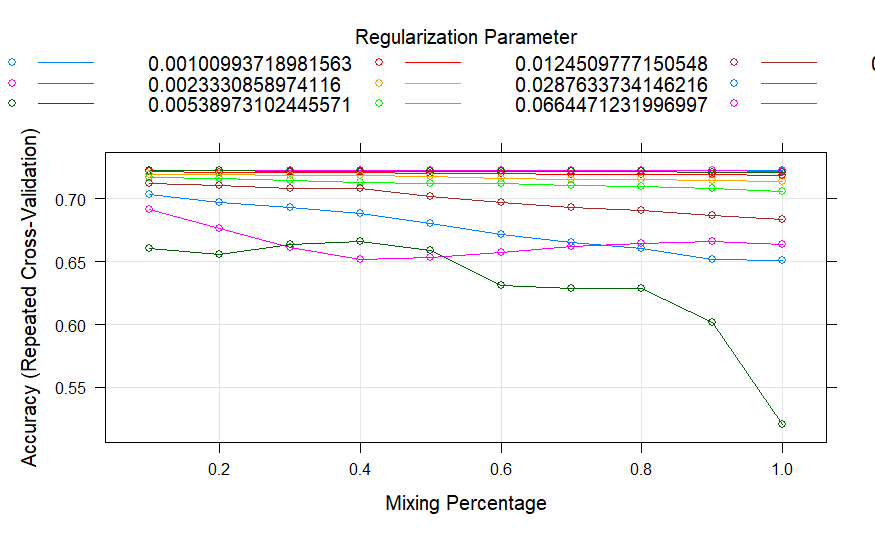

```r
plot(lr_clf_rfe)
```

Tuning done.

```r
lr_metrics_rfe <- evaluate_model(lr_clf_rfe, "LR", test_set_rfe)
```

```
Confusion Matrix and Statistics

          Reference
Prediction Low Moderate High
  Low       65       28    3
  Moderate  30       90    9
  High       1        7    8

Overall Statistics

               Accuracy : 0.6763
                 95% CI : (0.6133, 0.735)
    No Information Rate : 0.5187
    P-Value [Acc > NIR] : 4.979e-07

                  Kappa : 0.4202

 Mcnemar's Test P-Value : 0.7246

Statistics by Class:

                     Class: Low Class: Moderate Class: High
Precision                0.6771          0.6977     0.50000
Recall                   0.6771          0.7200     0.40000
F1                       0.6771          0.7087     0.44444
Prevalence               0.3983          0.5187     0.08299
Detection Rate           0.2697          0.3734     0.03320
Detection Prevalence     0.3983          0.5353     0.06639
Balanced Accuracy        0.7316          0.6919     0.68190
```

#### K-Nearest Neighbors

##### Train Set

```r
knn_clf <- train_model("knn")
```

```
k-Nearest Neighbors

964 samples
 13 predictor
  3 classes: 'Low', 'Moderate', 'High'

No pre-processing
Resampling: Cross-Validated (10 fold, repeated 10 times)
Summary of sample sizes: 868, 868, 868, 868, 867, 868, ...
Resampling results across tuning parameters:

  k  Accuracy   Kappa
  5  0.7235105  0.4988316
  7  0.6870028  0.4304988
  9  0.6878469  0.4272413

Accuracy was used to select the optimal model using the largest value.
The final value used for the model was k = 5.
```

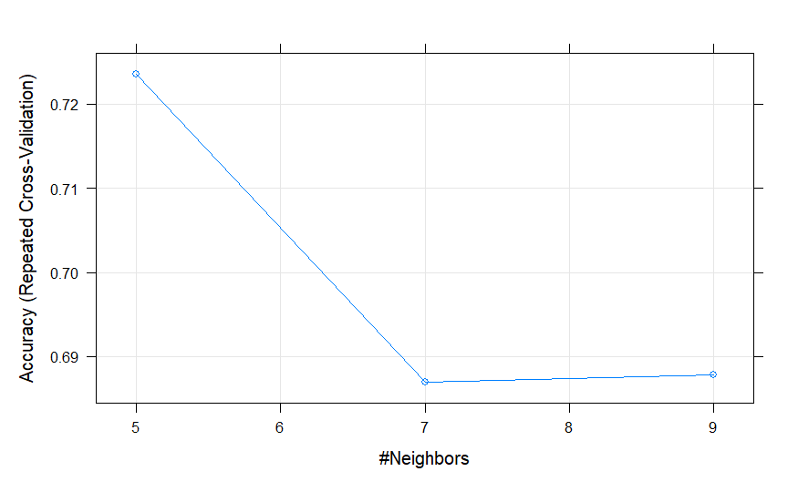

```r
plot(knn_clf)
```

Perform hyperparameter tuning using `tuneGrid`.

```r
knn_tuneGrid <- expand.grid(k = 1:5)

knn_clf <- train_model("knn", tuneGrid = knn_tuneGrid)
```

```
k-Nearest Neighbors

964 samples
 13 predictor
  3 classes: 'Low', 'Moderate', 'High'

No pre-processing
Resampling: Cross-Validated (10 fold, repeated 10 times)
Summary of sample sizes: 868, 868, 868, 868, 867, 868, ...
Resampling results across tuning parameters:

  k  Accuracy   Kappa
  1  0.8997766  0.8216863
  2  0.8299635  0.6947466
  3  0.7613832  0.5699109
  4  0.7389852  0.5287969
  5  0.7242375  0.5002350

Accuracy was used to select the optimal model using the largest value.
The final value used for the model was k = 1.
```

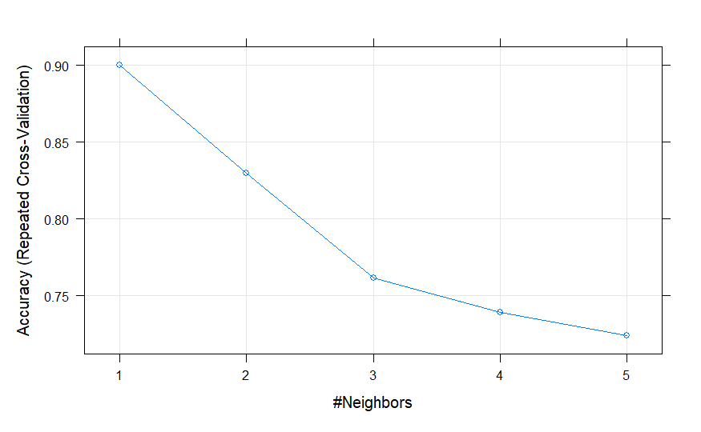

```r
plot(knn_clf)
```

Tuning done.

```r
knn_metrics <- evaluate_model(knn_clf, "KNN")
```

```
Confusion Matrix and Statistics

          Reference
Prediction Low Moderate High
  Low       89        6    0
  Moderate   6      119    6
  High       1        0   14

Overall Statistics

               Accuracy : 0.9212
                 95% CI : (0.8796, 0.9519)
    No Information Rate : 0.5187
    P-Value [Acc > NIR] : <2e-16

                  Kappa : 0.8582

 Mcnemar's Test P-Value : 0.0719

Statistics by Class:

                     Class: Low Class: Moderate Class: High
Precision                0.9368          0.9084     0.93333
Recall                   0.9271          0.9520     0.70000
F1                       0.9319          0.9297     0.80000
Prevalence               0.3983          0.5187     0.08299
Detection Rate           0.3693          0.4938     0.05809
Detection Prevalence     0.3942          0.5436     0.06224
Balanced Accuracy        0.9429          0.9243     0.84774
```

##### Train Set (RFE)

```r
knn_clf_rfe <- train_model("knn", train_set_rfe)
```

```
k-Nearest Neighbors

964 samples
 12 predictor
  3 classes: 'Low', 'Moderate', 'High'

No pre-processing
Resampling: Cross-Validated (10 fold, repeated 10 times)
Summary of sample sizes: 868, 868, 868, 868, 867, 868, ...
Resampling results across tuning parameters:

  k  Accuracy   Kappa
  5  0.7284966  0.5086594
  7  0.6988305  0.4534414
  9  0.7006970  0.4516860

Accuracy was used to select the optimal model using the largest value.
The final value used for the model was k = 5.
```

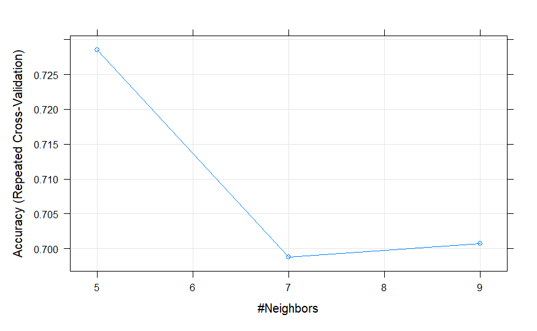

```r
plot(knn_clf_rfe)
```

Perform hyperparameter tuning using `tuneGrid`.

```r
knn_tuneGrid_rfe <- expand.grid(k = 1:5)

knn_clf_rfe <- train_model("knn", train_set_rfe, tuneGrid = knn_tuneGrid_rfe)
```

```
k-Nearest Neighbors

964 samples
 12 predictor
  3 classes: 'Low', 'Moderate', 'High'

No pre-processing
Resampling: Cross-Validated (10 fold, repeated 10 times)
Summary of sample sizes: 868, 868, 868, 868, 867, 868, ...
Resampling results across tuning parameters:

  k  Accuracy   Kappa
  1  0.8900268  0.8040775
  2  0.8250838  0.6857522
  3  0.7588037  0.5656063
  4  0.7409515  0.5325970
  5  0.7276514  0.5070115

Accuracy was used to select the optimal model using the largest value.
The final value used for the model was k = 1.
```

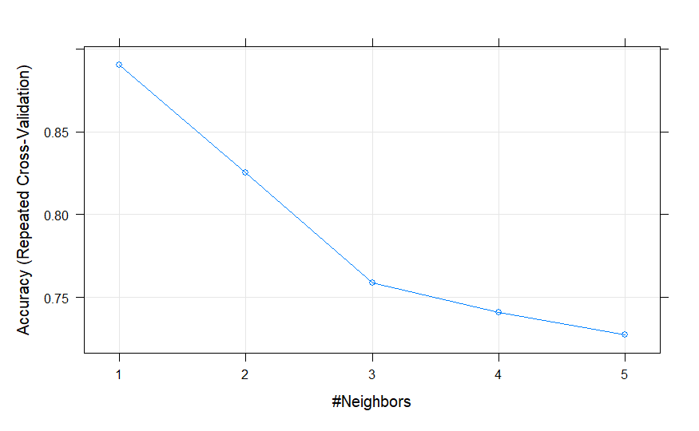

```r
plot(knn_clf_rfe)
```

Tuning done.

```r
knn_metrics_rfe <- evaluate_model(knn_clf_rfe, "KNN", test_set_rfe)
```

```
Confusion Matrix and Statistics

          Reference
Prediction Low Moderate High
  Low       88       11    0
  Moderate   7      114    6
  High       1        0   14

Overall Statistics

               Accuracy : 0.8963
                 95% CI : (0.8507, 0.9317)
    No Information Rate : 0.5187
    P-Value [Acc > NIR] : < 2e-16

                  Kappa : 0.8141

 Mcnemar's Test P-Value : 0.04836

Statistics by Class:

                     Class: Low Class: Moderate Class: High
Precision                0.8889          0.8976     0.93333
Recall                   0.9167          0.9120     0.70000
F1                       0.9026          0.9048     0.80000
Prevalence               0.3983          0.5187     0.08299
Detection Rate           0.3651          0.4730     0.05809
Detection Prevalence     0.4108          0.5270     0.06224
Balanced Accuracy        0.9204          0.9000     0.84774
```

#### Naive Bayes

##### Train Set

```r
nb_clf <- train_model("naive_bayes")
```

```
Naive Bayes

964 samples
 13 predictor
  3 classes: 'Low', 'Moderate', 'High'

No pre-processing
Resampling: Cross-Validated (10 fold, repeated 10 times)
Summary of sample sizes: 868, 868, 868, 868, 867, 868, ...
Resampling results across tuning parameters:

  usekernel  Accuracy   Kappa
  FALSE      0.6108870  0.3396469
   TRUE      0.6487575  0.3182251

Tuning parameter 'laplace' was held constant at a value of 0
Tuning
 parameter 'adjust' was held constant at a value of 1
Accuracy was used to select the optimal model using the largest value.
The final values used for the model were laplace = 0, usekernel = TRUE
 and adjust = 1.
```

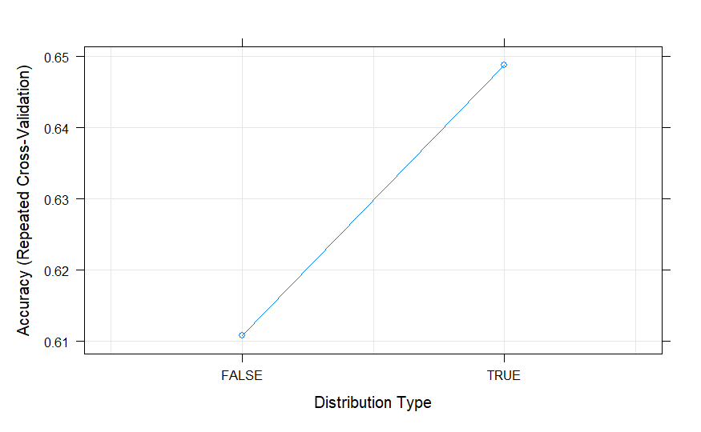

```r
plot(nb_clf)
```

Perform hyperparameter tuning using `tuneGrid`.

```r
nb_tuneGrid <- expand.grid(
  adjust = 1,
  usekernel = TRUE,
  laplace = seq(0.1, 1, 0.1)
)

nb_clf <- train_model("naive_bayes", tuneGrid = nb_tuneGrid)
```

```
Naive Bayes

964 samples
 13 predictor
  3 classes: 'Low', 'Moderate', 'High'

No pre-processing
Resampling: Cross-Validated (10 fold, repeated 10 times)
Summary of sample sizes: 868, 868, 868, 868, 867, 868, ...
Resampling results across tuning parameters:

  laplace  Accuracy   Kappa
  0.1      0.6487575  0.3182251
  0.2      0.6487575  0.3182251
  0.3      0.6487575  0.3182251
  0.4      0.6487575  0.3182251
  0.5      0.6487575  0.3182251
  0.6      0.6487575  0.3182251
  0.7      0.6487575  0.3182251
  0.8      0.6487575  0.3182251
  0.9      0.6487575  0.3182251
  1.0      0.6487575  0.3182251

Tuning parameter 'usekernel' was held constant at a value of TRUE

Tuning parameter 'adjust' was held constant at a value of 1
Accuracy was used to select the optimal model using the largest value.
The final values used for the model were laplace = 0.1, usekernel = TRUE
 and adjust = 1.
```

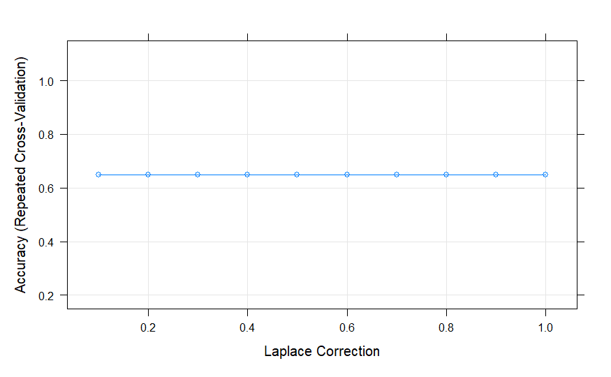

```r
plot(nb_clf)
```

Tuning done.

```r
nb_metrics <- evaluate_model(nb_clf, "NB")
```

```
Confusion Matrix and Statistics

          Reference
Prediction Low Moderate High
  Low       52       19    5
  Moderate  44      105   15
  High       0        1    0

Overall Statistics

               Accuracy : 0.6515
                 95% CI : (0.5876, 0.7115)
    No Information Rate : 0.5187
    P-Value [Acc > NIR] : 2.099e-05

                  Kappa : 0.3311

 Mcnemar's Test P-Value : 5.422e-06

Statistics by Class:

                     Class: Low Class: Moderate Class: High
Precision                0.6842          0.6402    0.000000
Recall                   0.5417          0.8400    0.000000
F1                       0.6047          0.7266         NaN
Prevalence               0.3983          0.5187    0.082988
Detection Rate           0.2158          0.4357    0.000000
Detection Prevalence     0.3154          0.6805    0.004149
Balanced Accuracy        0.6881          0.6657    0.497738
```

##### Train Set (RFE)

```r
nb_clf_rfe <- train_model("naive_bayes", train_set_rfe)
```

```
Naive Bayes

964 samples
 12 predictor
  3 classes: 'Low', 'Moderate', 'High'

No pre-processing
Resampling: Cross-Validated (10 fold, repeated 10 times)
Summary of sample sizes: 868, 868, 868, 868, 867, 868, ...
Resampling results across tuning parameters:

  usekernel  Accuracy   Kappa
  FALSE      0.6044523  0.3310951
   TRUE      0.6558097  0.3353134

Tuning parameter 'laplace' was held constant at a value of 0
Tuning
 parameter 'adjust' was held constant at a value of 1
Accuracy was used to select the optimal model using the largest value.
The final values used for the model were laplace = 0, usekernel = TRUE
 and adjust = 1.
```

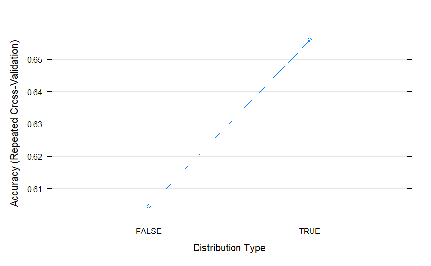

```r
plot(nb_clf_rfe)
```

Perform hyperparameter tuning using `tuneGrid`.

```r
nb_tuneGrid_rfe <- expand.grid(
  adjust = 1,
  usekernel = TRUE,
  laplace = seq(0.1, 1, 0.1)
)

nb_clf_rfe <- train_model(
  "naive_bayes",
  train_set_rfe,
  tuneGrid = nb_tuneGrid_rfe
)
```

```
Naive Bayes

964 samples
 12 predictor
  3 classes: 'Low', 'Moderate', 'High'

No pre-processing
Resampling: Cross-Validated (10 fold, repeated 10 times)
Summary of sample sizes: 868, 868, 868, 868, 867, 868, ...
Resampling results across tuning parameters:

  laplace  Accuracy   Kappa
  0.1      0.6558097  0.3353134
  0.2      0.6558097  0.3353134
  0.3      0.6558097  0.3353134
  0.4      0.6558097  0.3353134
  0.5      0.6558097  0.3353134
  0.6      0.6558097  0.3353134
  0.7      0.6558097  0.3353134
  0.8      0.6558097  0.3353134
  0.9      0.6558097  0.3353134
  1.0      0.6558097  0.3353134

Tuning parameter 'usekernel' was held constant at a value of TRUE

Tuning parameter 'adjust' was held constant at a value of 1
Accuracy was used to select the optimal model using the largest value.
The final values used for the model were laplace = 0.1, usekernel = TRUE
 and adjust = 1.
```

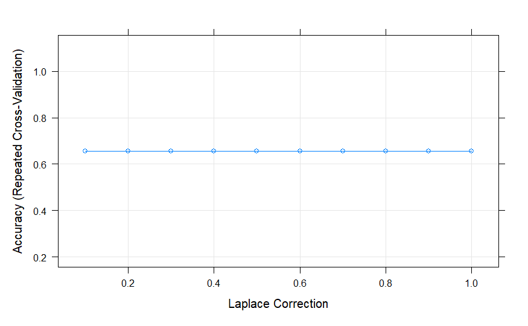

```r
plot(nb_clf_rfe)
```

Tuning done.

```r
nb_metrics_rfe <- evaluate_model(nb_clf_rfe, "NB", test_set_rfe)
```

```
Confusion Matrix and Statistics

          Reference
Prediction Low Moderate High
  Low       52       21    5
  Moderate  44      103   15
  High       0        1    0

Overall Statistics

               Accuracy : 0.6432
                 95% CI : (0.5791, 0.7036)
    No Information Rate : 0.5187
    P-Value [Acc > NIR] : 6.341e-05

                  Kappa : 0.3165

 Mcnemar's Test P-Value : 1.281e-05

Statistics by Class:

                     Class: Low Class: Moderate Class: High
Precision                0.6667          0.6358    0.000000
Recall                   0.5417          0.8240    0.000000
F1                       0.5977          0.7178         NaN
Prevalence               0.3983          0.5187    0.082988
Detection Rate           0.2158          0.4274    0.000000
Detection Prevalence     0.3237          0.6722    0.004149
Balanced Accuracy        0.6812          0.6577    0.497738
```

#### Decision Tree

##### Train Set

```r
dt_clf <- train_model("rpart2")
```

```
CART

964 samples
 13 predictor
  3 classes: 'Low', 'Moderate', 'High'

No pre-processing
Resampling: Cross-Validated (10 fold, repeated 10 times)
Summary of sample sizes: 868, 868, 868, 868, 867, 868, ...
Resampling results across tuning parameters:

  maxdepth  Accuracy   Kappa
  1         0.6286351  0.2509468
  4         0.6726138  0.3886074
  6         0.7062446  0.4657412

Accuracy was used to select the optimal model using the largest value.
The final value used for the model was maxdepth = 6.
```

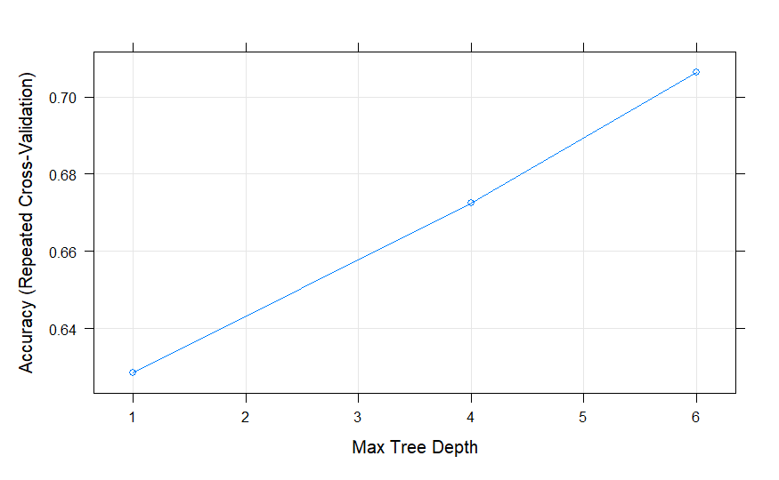

```r
plot(dt_clf)
```

Perform hyperparameter tuning using `tuneLength`.

```r
dt_clf <- train_model("rpart2", tuneLength = 10)
```

```
CART

964 samples
 13 predictor
  3 classes: 'Low', 'Moderate', 'High'

No pre-processing
Resampling: Cross-Validated (10 fold, repeated 10 times)
Summary of sample sizes: 868, 868, 868, 868, 867, 868, ...
Resampling results across tuning parameters:

  maxdepth  Accuracy   Kappa
   1        0.6286351  0.2509468
   4        0.6726138  0.3886074
   6        0.6827921  0.4183524
   7        0.6869308  0.4240164
  12        0.7149474  0.4848606
  17        0.7148464  0.4850786
  19        0.7148464  0.4850786
  22        0.7148464  0.4850786
  23        0.7148464  0.4850786
  26        0.7148464  0.4850786

Accuracy was used to select the optimal model using the largest value.
The final value used for the model was maxdepth = 12.
```

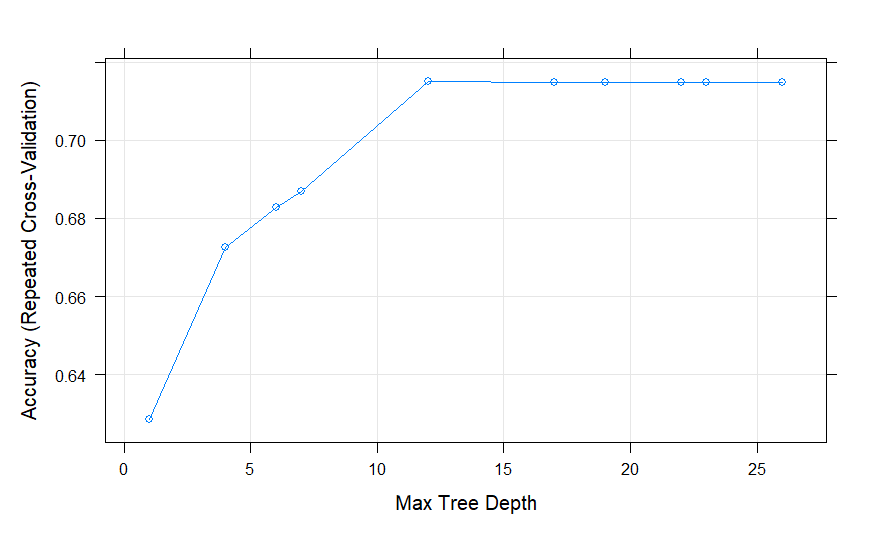

```r
plot(dt_clf)
```

Tuning done.

```r
dt_metrics <- evaluate_model(dt_clf, "DT")
```

```
Confusion Matrix and Statistics

          Reference
Prediction Low Moderate High
  Low       63       17    2
  Moderate  32      102    8
  High       1        6   10

Overall Statistics

               Accuracy : 0.7261
                 95% CI : (0.6652, 0.7814)
    No Information Rate : 0.5187
    P-Value [Acc > NIR] : 3.74e-11

                  Kappa : 0.5048

 Mcnemar's Test P-Value : 0.157

Statistics by Class:

                     Class: Low Class: Moderate Class: High
Precision                0.7683          0.7183     0.58824
Recall                   0.6562          0.8160     0.50000
F1                       0.7079          0.7640     0.54054
Prevalence               0.3983          0.5187     0.08299
Detection Rate           0.2614          0.4232     0.04149
Detection Prevalence     0.3402          0.5892     0.07054
Balanced Accuracy        0.7626          0.7356     0.73416
```

##### Train Set (RFE)

```r
dt_clf_rfe <- train_model("rpart2", train_set_rfe)
```

```
CART

964 samples
 12 predictor
  3 classes: 'Low', 'Moderate', 'High'

No pre-processing
Resampling: Cross-Validated (10 fold, repeated 10 times)
Summary of sample sizes: 868, 868, 868, 868, 867, 868, ...
Resampling results across tuning parameters:

  maxdepth  Accuracy   Kappa
  1         0.6286351  0.2509468
  4         0.6726138  0.3886074
  6         0.7062446  0.4657412

Accuracy was used to select the optimal model using the largest value.
The final value used for the model was maxdepth = 6.
```

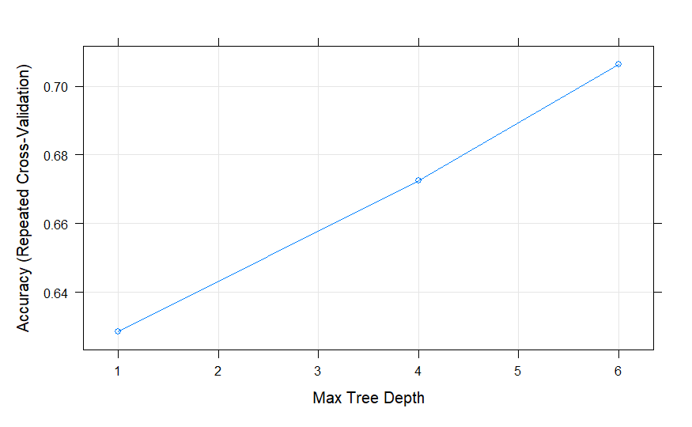

```r
plot(dt_clf_rfe)
```

Perform hyperparameter tuning using `tuneLength`.

```r
dt_clf_rfe <- train_model("rpart2", train_set_rfe, tuneLength = 10)
```

```
CART

964 samples
 12 predictor
  3 classes: 'Low', 'Moderate', 'High'

No pre-processing
Resampling: Cross-Validated (10 fold, repeated 10 times)
Summary of sample sizes: 868, 868, 868, 868, 867, 868, ...
Resampling results across tuning parameters:

  maxdepth  Accuracy   Kappa
   1        0.6286351  0.2509468
   4        0.6726138  0.3886074
   6        0.6827921  0.4183524
   7        0.6869308  0.4240164
  12        0.7143235  0.4835574
  17        0.7142225  0.4837804
  19        0.7142225  0.4837804
  22        0.7142225  0.4837804
  23        0.7142225  0.4837804
  26        0.7142225  0.4837804

Accuracy was used to select the optimal model using the largest value.
The final value used for the model was maxdepth = 12.
```

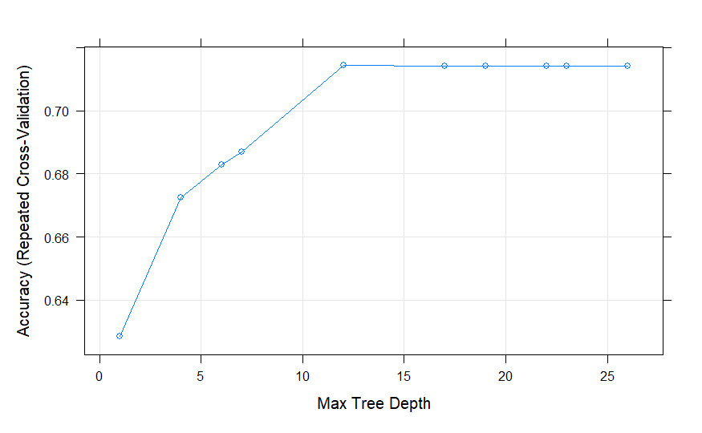

```r
plot(dt_clf_rfe)
```

Tuning done.

```r
dt_metrics_rfe <- evaluate_model(dt_clf_rfe, "DT", test_set_rfe)
```

```
Confusion Matrix and Statistics

          Reference
Prediction Low Moderate High
  Low       63       17    2
  Moderate  32      102    8
  High       1        6   10

Overall Statistics

               Accuracy : 0.7261
                 95% CI : (0.6652, 0.7814)
    No Information Rate : 0.5187
    P-Value [Acc > NIR] : 3.74e-11

                  Kappa : 0.5048

 Mcnemar's Test P-Value : 0.157

Statistics by Class:

                     Class: Low Class: Moderate Class: High
Precision                0.7683          0.7183     0.58824
Recall                   0.6562          0.8160     0.50000
F1                       0.7079          0.7640     0.54054
Prevalence               0.3983          0.5187     0.08299
Detection Rate           0.2614          0.4232     0.04149
Detection Prevalence     0.3402          0.5892     0.07054
Balanced Accuracy        0.7626          0.7356     0.73416
```

#### Random Forest

##### Train Set

```r
rf_clf <- train_model("ranger")
```

```
Random Forest

964 samples
 13 predictor
  3 classes: 'Low', 'Moderate', 'High'

No pre-processing
Resampling: Cross-Validated (10 fold, repeated 10 times)
Summary of sample sizes: 868, 868, 868, 868, 867, 868, ...
Resampling results across tuning parameters:

  mtry  splitrule   Accuracy   Kappa
   2    gini        0.7847584  0.6012405
   2    extratrees  0.7836115  0.5970009
  12    gini        0.9029940  0.8265270
  12    extratrees  0.9038284  0.8281071
  22    gini        0.9034074  0.8278398
  22    extratrees  0.9057968  0.8322343

Tuning parameter 'min.node.size' was held constant at a value of 1
Accuracy was used to select the optimal model using the largest value.
The final values used for the model were mtry = 22, splitrule =
 extratrees and min.node.size = 1.
```

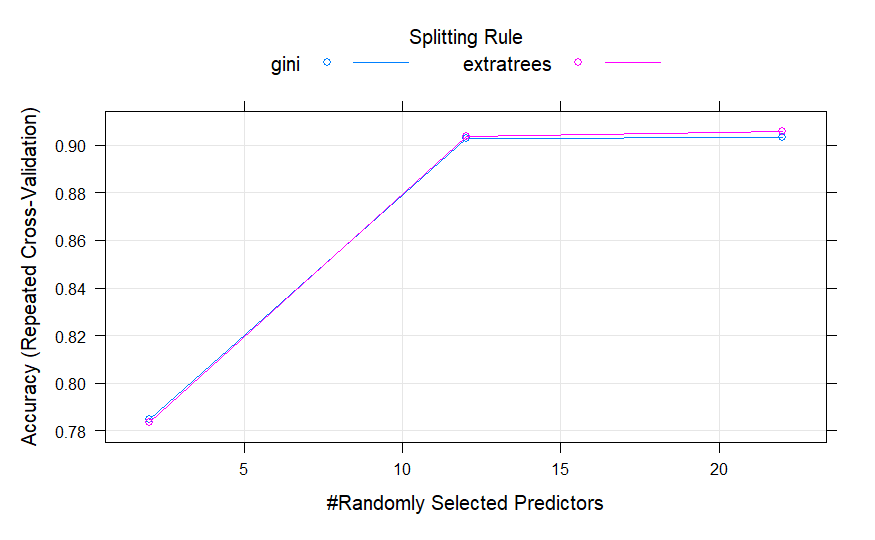

```r
plot(rf_clf)
```

Perform hyperparameter tuning using `tuneLength`.

```r
rf_clf <- train_model("ranger", tuneLength = 10)
```

```
Random Forest

964 samples
 13 predictor
  3 classes: 'Low', 'Moderate', 'High'

No pre-processing
Resampling: Cross-Validated (10 fold, repeated 10 times)
Summary of sample sizes: 868, 868, 868, 868, 867, 868, ...
Resampling results across tuning parameters:

  mtry  splitrule   Accuracy   Kappa
   2    gini        0.7826740  0.5973822
   2    extratrees  0.7852760  0.6001566
   4    gini        0.8390099  0.7080303
   4    extratrees  0.8475086  0.7229155
   6    gini        0.8816280  0.7865702
   6    extratrees  0.8818299  0.7869535
   8    gini        0.8937693  0.8091480
   8    extratrees  0.8944910  0.8105418
  10    gini        0.8995769  0.8199832
  10    extratrees  0.9000999  0.8211079
  13    gini        0.9054865  0.8312448
  13    extratrees  0.9054875  0.8312553
  15    gini        0.9067311  0.8337661
  15    extratrees  0.9061093  0.8325781
  17    gini        0.9057968  0.8320778
  17    extratrees  0.9075591  0.8352827
  19    gini        0.9039283  0.8287270
  19    extratrees  0.9073540  0.8349163
  22    gini        0.9038230  0.8286413
  22    extratrees  0.9043417  0.8296482

Tuning parameter 'min.node.size' was held constant at a value of 1
Accuracy was used to select the optimal model using the largest value.
The final values used for the model were mtry = 17, splitrule =
 extratrees and min.node.size = 1.
```

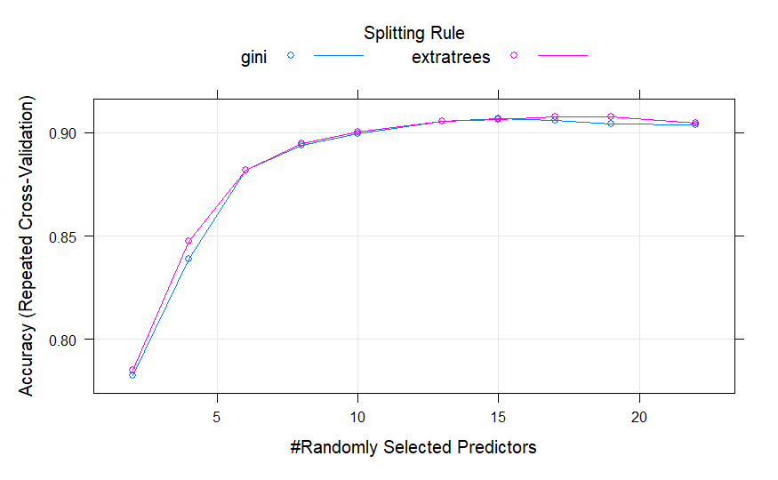

```r
plot(rf_clf)
```

Tuning done.

```r
rf_metrics <- evaluate_model(rf_clf, "RF")
```

```
Confusion Matrix and Statistics

          Reference
Prediction Low Moderate High
  Low       89        6    0
  Moderate   6      119    6
  High       1        0   14

Overall Statistics

               Accuracy : 0.9212
                 95% CI : (0.8796, 0.9519)
    No Information Rate : 0.5187
    P-Value [Acc > NIR] : <2e-16

                  Kappa : 0.8582

 Mcnemar's Test P-Value : 0.0719

Statistics by Class:

                     Class: Low Class: Moderate Class: High
Precision                0.9368          0.9084     0.93333
Recall                   0.9271          0.9520     0.70000
F1                       0.9319          0.9297     0.80000
Prevalence               0.3983          0.5187     0.08299
Detection Rate           0.3693          0.4938     0.05809
Detection Prevalence     0.3942          0.5436     0.06224
Balanced Accuracy        0.9429          0.9243     0.84774
```

##### Train Set (RFE)

```r
rf_clf_rfe <- train_model("ranger", train_set_rfe)
```

```
Random Forest

964 samples
 12 predictor
  3 classes: 'Low', 'Moderate', 'High'

No pre-processing
Resampling: Cross-Validated (10 fold, repeated 10 times)
Summary of sample sizes: 868, 868, 868, 868, 867, 868, ...
Resampling results across tuning parameters:

  mtry  splitrule   Accuracy   Kappa
   2    gini        0.7821488  0.5962785
   2    extratrees  0.7817354  0.5932279
  11    gini        0.8898239  0.8029102
  11    extratrees  0.8912801  0.8056031
  21    gini        0.8942826  0.8116065
  21    extratrees  0.8956282  0.8140780

Tuning parameter 'min.node.size' was held constant at a value of 1
Accuracy was used to select the optimal model using the largest value.
The final values used for the model were mtry = 21, splitrule =
 extratrees and min.node.size = 1.
```

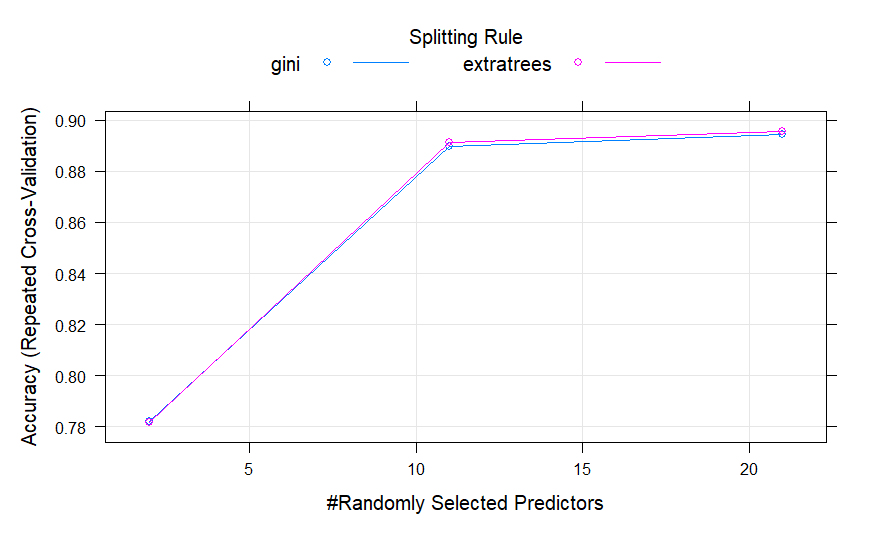

```r
plot(rf_clf_rfe)
```

Perform hyperparameter tuning using `tuneLength`.

```r
rf_clf_rfe <- train_model("ranger", train_set_rfe, tuneLength = 10)
```

```
Random Forest

964 samples
 12 predictor
  3 classes: 'Low', 'Moderate', 'High'

No pre-processing
Resampling: Cross-Validated (10 fold, repeated 10 times)
Summary of sample sizes: 868, 868, 868, 868, 867, 868, ...
Resampling results across tuning parameters:

  mtry  splitrule   Accuracy   Kappa
   2    gini        0.7831830  0.5982840
   2    extratrees  0.7834933  0.5968021
   4    gini        0.8342365  0.6990536
   4    extratrees  0.8409708  0.7111616
   6    gini        0.8699087  0.7656132
   6    extratrees  0.8727073  0.7706322
   8    gini        0.8819416  0.7881849
   8    extratrees  0.8826622  0.7894480
  10    gini        0.8879553  0.7994832
  10    extratrees  0.8900311  0.8031478
  12    gini        0.8918976  0.8069934
  12    extratrees  0.8925193  0.8081101
  14    gini        0.8948013  0.8126189
  14    extratrees  0.8946972  0.8123815
  16    gini        0.8952126  0.8133759
  16    extratrees  0.8956314  0.8141024
  18    gini        0.8941774  0.8113259
  18    extratrees  0.8959386  0.8146803
  21    gini        0.8939669  0.8111654
  21    extratrees  0.8962532  0.8151557

Tuning parameter 'min.node.size' was held constant at a value of 1
Accuracy was used to select the optimal model using the largest value.
The final values used for the model were mtry = 21, splitrule =
 extratrees and min.node.size = 1.
```

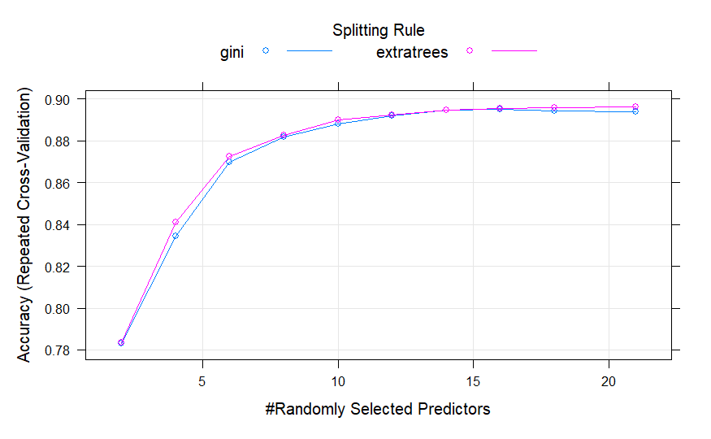

```r
plot(rf_clf_rfe)
```

Tuning done.

```r
rf_metrics_rfe <- evaluate_model(rf_clf_rfe, "RF", test_set_rfe)
```

```
Confusion Matrix and Statistics

          Reference
Prediction Low Moderate High
  Low       86        6    0
  Moderate   9      118    6
  High       1        1   14

Overall Statistics

               Accuracy : 0.9046
                 95% CI : (0.8602, 0.9385)
    No Information Rate : 0.5187
    P-Value [Acc > NIR] : <2e-16

                  Kappa : 0.8284

 Mcnemar's Test P-Value : 0.1597

Statistics by Class:

                     Class: Low Class: Moderate Class: High
Precision                0.9348          0.8872     0.87500
Recall                   0.8958          0.9440     0.70000
F1                       0.9149          0.9147     0.77778
Prevalence               0.3983          0.5187     0.08299
Detection Rate           0.3568          0.4896     0.05809
Detection Prevalence     0.3817          0.5519     0.06639
Balanced Accuracy        0.9272          0.9073     0.84548
```

#### XGBoost (Tree)

Define a helper function to train XGBoost model with less verbose output.

```r
train_xgb <- function(method = "",
                        data = train_set,
                        tuneGrid = NULL,
                        tuneLength = 3) {
  set.seed(42)

  fit <- train(
    Adaptivity.Level ~ .,
    data = data,
    method = method,
    trControl = fit_control,
    tuneGrid = tuneGrid,
    tuneLength = tuneLength,
    verbosity = 0
  )

  print(fit)

  return(fit)
}
```

##### Train Set

```r
xgb_tree_clf <- train_xgb("xgbTree")
```

```
eXtreme Gradient Boosting

964 samples
 13 predictor
  3 classes: 'Low', 'Moderate', 'High'

No pre-processing
Resampling: Cross-Validated (10 fold, repeated 10 times)
Summary of sample sizes: 868, 868, 868, 868, 867, 868, ...
Resampling results across tuning parameters:

  eta  max_depth  colsample_bytree  subsample  nrounds  Accuracy   Kappa
  0.3  1          0.6               0.50        50      0.6801783  0.3993658
  0.3  1          0.6               0.50       100      0.7056003  0.4553205
  0.3  1          0.6               0.50       150      0.7106873  0.4667460
  0.3  1          0.6               0.75        50      0.6756250  0.3876681
  0.3  1          0.6               0.75       100      0.7063413  0.4561418
  0.3  1          0.6               0.75       150      0.7119308  0.4692089
  0.3  1          0.6               1.00        50      0.6687683  0.3699969
  0.3  1          0.6               1.00       100      0.6988671  0.4384598
  0.3  1          0.6               1.00       150      0.7062307  0.4562201
  0.3  1          0.8               0.50        50      0.6841323  0.4085121
  0.3  1          0.8               0.50       100      0.7070586  0.4589963
  0.3  1          0.8               0.50       150      0.7138091  0.4736262
  0.3  1          0.8               0.75        50      0.6806132  0.3980225
  0.3  1          0.8               0.75       100      0.7071607  0.4582979
  0.3  1          0.8               0.75       150      0.7123421  0.4704831
  0.3  1          0.8               1.00        50      0.6670071  0.3667858
  0.3  1          0.8               1.00       100      0.6980326  0.4367162
  0.3  1          0.8               1.00       150      0.7057109  0.4550202
  0.3  2          0.6               0.50        50      0.7468782  0.5360967
  0.3  2          0.6               0.50       100      0.7710610  0.5839717
  0.3  2          0.6               0.50       150      0.7902427  0.6196981
  0.3  2          0.6               0.75        50      0.7498765  0.5402727
  0.3  2          0.6               0.75       100      0.7764454  0.5930363
  0.3  2          0.6               0.75       150      0.7964637  0.6310634
  0.3  2          0.6               1.00        50      0.7444985  0.5296396
  0.3  2          0.6               1.00       100      0.7667955  0.5742803
  0.3  2          0.6               1.00       150      0.7773722  0.5955512
  0.3  2          0.8               0.50        50      0.7535073  0.5485171
```

[output cut: 73 more lines]

```
  0.4  3          0.8               0.50       150      0.8710556  0.7688981
  0.4  3          0.8               0.75        50      0.8327652  0.6974927
  0.4  3          0.8               0.75       100      0.8650376  0.7575153
  0.4  3          0.8               0.75       150      0.8777899  0.7810994
  0.4  3          0.8               1.00        50      0.8183570  0.6705087
  0.4  3          0.8               1.00       100      0.8632657  0.7535896
  0.4  3          0.8               1.00       150      0.8745758  0.7746169

Tuning parameter 'gamma' was held constant at a value of 0
Tuning
 parameter 'min_child_weight' was held constant at a value of 1
Accuracy was used to select the optimal model using the largest value.
The final values used for the model were nrounds = 150, max_depth = 3, eta
 = 0.4, gamma = 0, colsample_bytree = 0.8, min_child_weight = 1 and
 subsample = 0.75.
```

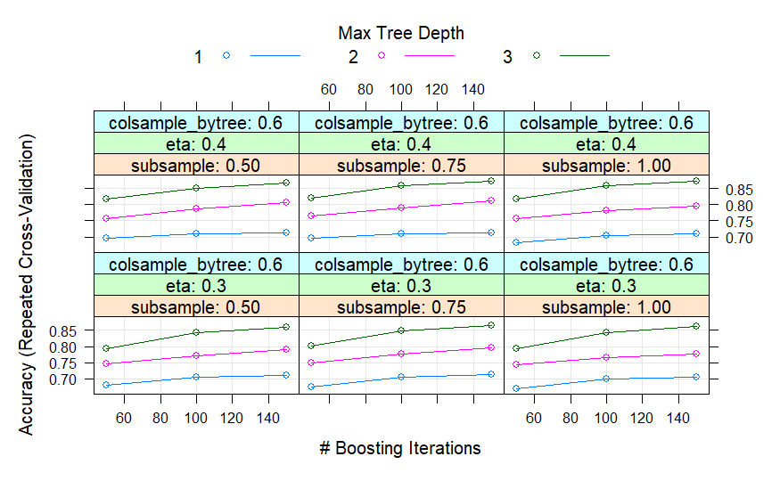

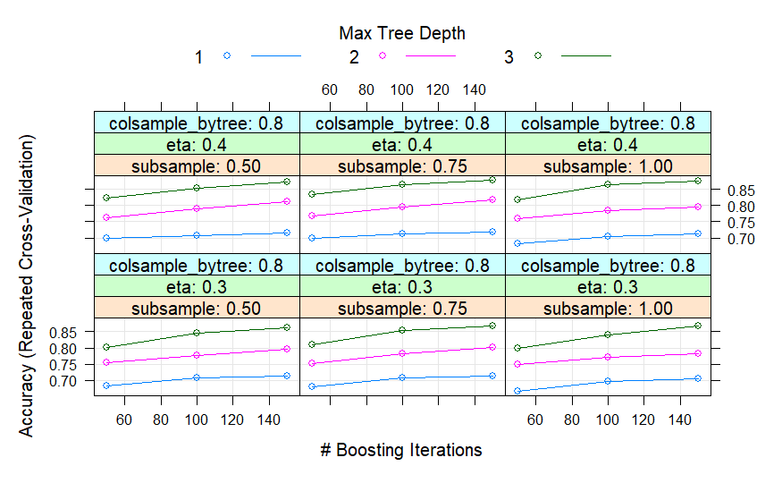

```r
plot(xgb_tree_clf)
```

Perform hyperparameter tuning using `tuneGrid`.

```r
xgb_tree_tuneGrid <- expand.grid(
  gamma = 0,
  min_child_weight = 1,
  max_depth = 3,
  eta = 0.4,
  subsample = seq(0.5, 1, 0.25),
  colsample_bytree = 0.8,
  nrounds = seq(100, 500, 10)
)

xgb_tree_clf <- train_xgb("xgbTree", tuneGrid = xgb_tree_tuneGrid)
```

```
eXtreme Gradient Boosting

964 samples
 13 predictor
  3 classes: 'Low', 'Moderate', 'High'

No pre-processing
Resampling: Cross-Validated (10 fold, repeated 10 times)
Summary of sample sizes: 868, 868, 868, 868, 867, 868, ...
Resampling results across tuning parameters:

  subsample  nrounds  Accuracy   Kappa
  0.50       100      0.8540399  0.7373741
  0.50       110      0.8573561  0.7442360
  0.50       120      0.8604747  0.7497736
  0.50       130      0.8630627  0.7543830
  0.50       140      0.8667000  0.7611362
  0.50       150      0.8660835  0.7599168
  0.50       160      0.8702298  0.7674641
  0.50       170      0.8712618  0.7693885
  0.50       180      0.8748883  0.7758197
  0.50       190      0.8755294  0.7768880
  0.50       200      0.8799807  0.7849932
  0.50       210      0.8800870  0.7851600
  0.50       220      0.8800784  0.7850765
  0.50       230      0.8828855  0.7901259
  0.50       240      0.8830939  0.7905369
  0.50       250      0.8839218  0.7919260
  0.50       260      0.8851697  0.7941515
  0.50       270      0.8866130  0.7968403
  0.50       280      0.8871402  0.7980154
  0.50       290      0.8870404  0.7976931
  0.50       300      0.8881723  0.7997298
  0.50       310      0.8900462  0.8030888
  0.50       320      0.8926364  0.8078086
  0.50       330      0.8923185  0.8073246
  0.50       340      0.8939734  0.8105075
  0.50       350      0.8939830  0.8102552
  0.50       360      0.8952266  0.8125842
  0.50       370      0.8950226  0.8123680
```

[output cut: 89 more lines]

```
  1.00       450      0.8997831  0.8210648
  1.00       460      0.9007163  0.8228477
  1.00       470      0.9014412  0.8241964
  1.00       480      0.9018600  0.8249481
  1.00       490      0.9025838  0.8262048
  1.00       500      0.9028920  0.8268263

Tuning parameter 'max_depth' was held constant at a value of 3
 parameter 'colsample_bytree' was held constant at a value of 0.8

Tuning parameter 'min_child_weight' was held constant at a value of 1
Accuracy was used to select the optimal model using the largest value.
The final values used for the model were nrounds = 460, max_depth = 3, eta
 = 0.4, gamma = 0, colsample_bytree = 0.8, min_child_weight = 1 and
 subsample = 0.75.
```

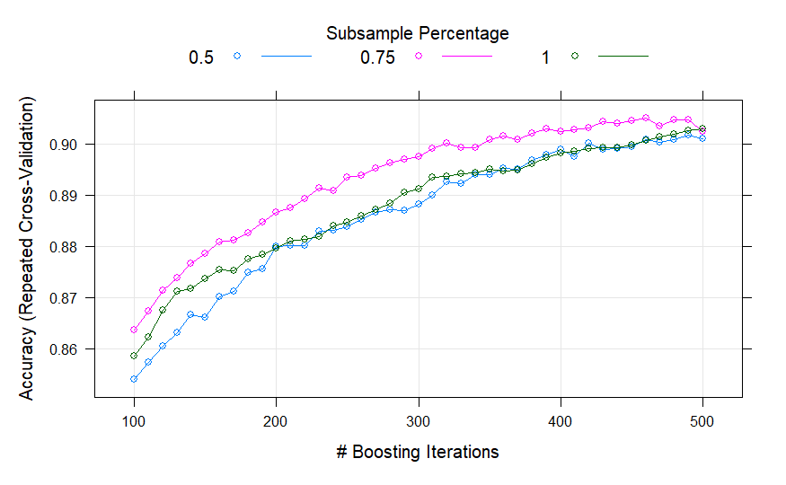

```r
plot(xgb_tree_clf)
```

Tuning done.

```r
xgb_tree_metrics <- evaluate_model(xgb_tree_clf, "XGB - Tree", family = "XGB")
```

```
Confusion Matrix and Statistics

          Reference
Prediction Low Moderate High
  Low       88        6    0
  Moderate   7      119    6
  High       1        0   14

Overall Statistics

               Accuracy : 0.917
                 95% CI : (0.8747, 0.9486)
    No Information Rate : 0.5187
    P-Value [Acc > NIR] : < 2e-16

                  Kappa : 0.8506

 Mcnemar's Test P-Value : 0.06949

Statistics by Class:

                     Class: Low Class: Moderate Class: High
Precision                0.9362          0.9015     0.93333
Recall                   0.9167          0.9520     0.70000
F1                       0.9263          0.9261     0.80000
Prevalence               0.3983          0.5187     0.08299
Detection Rate           0.3651          0.4938     0.05809
Detection Prevalence     0.3900          0.5477     0.06224
Balanced Accuracy        0.9376          0.9200     0.84774
```

##### Train Set (RFE)

```r
xgb_tree_clf_rfe <- train_xgb("xgbTree", train_set_rfe)
```

```
eXtreme Gradient Boosting

964 samples
 12 predictor
  3 classes: 'Low', 'Moderate', 'High'

No pre-processing
Resampling: Cross-Validated (10 fold, repeated 10 times)
Summary of sample sizes: 868, 868, 868, 868, 867, 868, ...
Resampling results across tuning parameters:

  eta  max_depth  colsample_bytree  subsample  nrounds  Accuracy   Kappa
  0.3  1          0.6               0.50        50      0.6824624  0.4036661
  0.3  1          0.6               0.50       100      0.7076858  0.4596006
  0.3  1          0.6               0.50       150      0.7131701  0.4721049
  0.3  1          0.6               0.75        50      0.6768610  0.3900554
  0.3  1          0.6               0.75       100      0.7053963  0.4544413
  0.3  1          0.6               0.75       150      0.7106830  0.4663465
  0.3  1          0.6               1.00        50      0.6686705  0.3698979
  0.3  1          0.6               1.00       100      0.6980294  0.4369249
  0.3  1          0.6               1.00       150      0.7054994  0.4547350
  0.3  1          0.8               0.50        50      0.6879736  0.4154900
  0.3  1          0.8               0.50       100      0.7111920  0.4661447
  0.3  1          0.8               0.50       150      0.7137973  0.4723275
  0.3  1          0.8               0.75        50      0.6770812  0.3908696
  0.3  1          0.8               0.75       100      0.7046703  0.4536411
  0.3  1          0.8               0.75       150      0.7123475  0.4707069
  0.3  1          0.8               1.00        50      0.6673196  0.3673890
  0.3  1          0.8               1.00       100      0.6975097  0.4356908
  0.3  1          0.8               1.00       150      0.7065399  0.4567063
  0.3  2          0.6               0.50        50      0.7509300  0.5430567
  0.3  2          0.6               0.50       100      0.7744706  0.5893523
  0.3  2          0.6               0.50       150      0.7871402  0.6137731
  0.3  2          0.6               0.75        50      0.7441871  0.5294652
  0.3  2          0.6               0.75       100      0.7751987  0.5905975
  0.3  2          0.6               0.75       150      0.7941763  0.6263855
  0.3  2          0.6               1.00        50      0.7391140  0.5191132
  0.3  2          0.6               1.00       100      0.7659783  0.5725994
  0.3  2          0.6               1.00       150      0.7843235  0.6084584
  0.3  2          0.8               0.50        50      0.7519663  0.5457091
```

[output cut: 73 more lines]

```
  0.4  3          0.8               0.50       150      0.8651471  0.7579883
  0.4  3          0.8               0.75        50      0.8219663  0.6770989
  0.4  3          0.8               0.75       100      0.8587135  0.7459845
  0.4  3          0.8               0.75       150      0.8716731  0.7698912
  0.4  3          0.8               1.00        50      0.8151267  0.6641472
  0.4  3          0.8               1.00       100      0.8527942  0.7345025
  0.4  3          0.8               1.00       150      0.8644137  0.7563810

Tuning parameter 'gamma' was held constant at a value of 0
Tuning
 parameter 'min_child_weight' was held constant at a value of 1
Accuracy was used to select the optimal model using the largest value.
The final values used for the model were nrounds = 150, max_depth = 3, eta
 = 0.4, gamma = 0, colsample_bytree = 0.8, min_child_weight = 1 and
 subsample = 0.75.
```

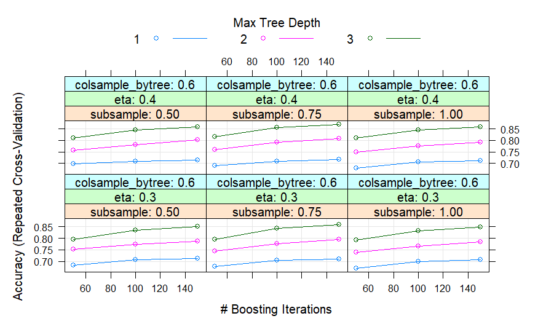

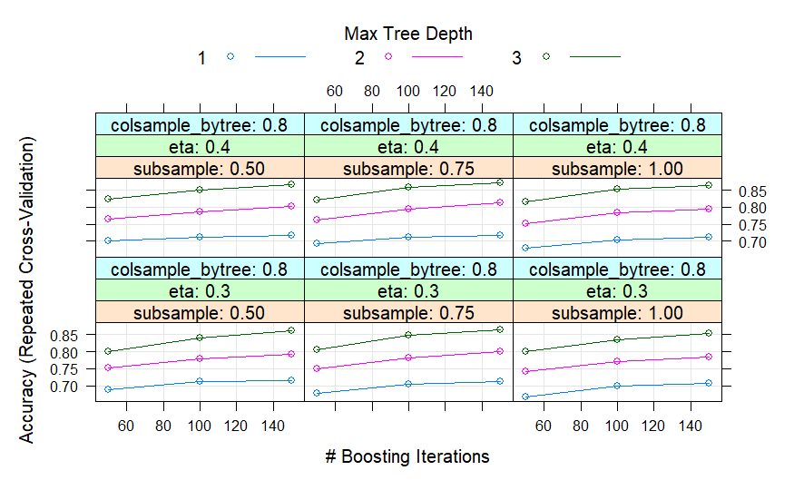

```r
plot(xgb_tree_clf_rfe)
```

Perform hyperparameter tuning using `tuneGrid`.

```r
xgb_tree_tuneGrid_rfe <- expand.grid(
  gamma = 0,
  min_child_weight = 1,
  max_depth = 3,
  eta = 0.4,
  subsample = seq(0.5, 1, 0.25),
  colsample_bytree = 0.8,
  nrounds = seq(100, 500, 10)
)

xgb_tree_clf_rfe <- train_xgb(
  "xgbTree",
  train_set_rfe,
  tuneGrid = xgb_tree_tuneGrid_rfe
)
```

```
eXtreme Gradient Boosting

964 samples
 12 predictor
  3 classes: 'Low', 'Moderate', 'High'

No pre-processing
Resampling: Cross-Validated (10 fold, repeated 10 times)
Summary of sample sizes: 868, 868, 868, 868, 867, 868, ...
Resampling results across tuning parameters:

  subsample  nrounds  Accuracy   Kappa
  0.50       100      0.8521725  0.7340851
  0.50       110      0.8547562  0.7384874
  0.50       120      0.8570372  0.7431201
  0.50       130      0.8617150  0.7516278
  0.50       140      0.8658698  0.7590137
  0.50       150      0.8669040  0.7611318
  0.50       160      0.8704328  0.7675113
  0.50       170      0.8687736  0.7646061
  0.50       180      0.8693847  0.7657317
  0.50       190      0.8732281  0.7726460
  0.50       200      0.8745812  0.7749182
  0.50       210      0.8739669  0.7739729
  0.50       220      0.8748819  0.7755758
  0.50       230      0.8783043  0.7817887
  0.50       240      0.8775859  0.7806223
  0.50       250      0.8764476  0.7783475
  0.50       260      0.8760417  0.7776269
  0.50       270      0.8780004  0.7812909
  0.50       280      0.8785159  0.7822268
  0.50       290      0.8770651  0.7797640
  0.50       300      0.8809064  0.7865754
  0.50       310      0.8793439  0.7836651
  0.50       320      0.8799732  0.7845706
  0.50       330      0.8814283  0.7874934
  0.50       340      0.8822530  0.7891478
  0.50       350      0.8823464  0.7890768
  0.50       360      0.8821413  0.7890186
  0.50       370      0.8823636  0.7894025
```

[output cut: 89 more lines]

```
  1.00       450      0.8880681  0.8000091
  1.00       460      0.8881723  0.8002769
  1.00       470      0.8887930  0.8014169
  1.00       480      0.8893159  0.8023986
  1.00       490      0.8891087  0.8020387
  1.00       500      0.8892107  0.8022143

Tuning parameter 'max_depth' was held constant at a value of 3
 parameter 'colsample_bytree' was held constant at a value of 0.8

Tuning parameter 'min_child_weight' was held constant at a value of 1
Accuracy was used to select the optimal model using the largest value.
The final values used for the model were nrounds = 490, max_depth = 3, eta
 = 0.4, gamma = 0, colsample_bytree = 0.8, min_child_weight = 1 and
 subsample = 0.75.
```

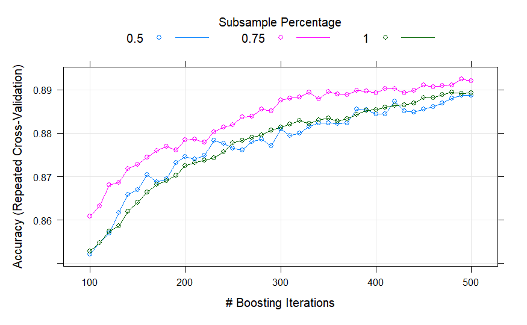

```r
plot(xgb_tree_clf_rfe)
```

Tuning done.

```r
xgb_tree_metrics_rfe <- evaluate_model(
  xgb_tree_clf_rfe,
  "XGB - Tree",
  test_set_rfe,
  "XGB"
)
```

```
Confusion Matrix and Statistics

          Reference
Prediction Low Moderate High
  Low       84       10    0
  Moderate  11      115    6
  High       1        0   14

Overall Statistics

               Accuracy : 0.8838
                 95% CI : (0.8365, 0.9214)
    No Information Rate : 0.5187
    P-Value [Acc > NIR] : <2e-16

                  Kappa : 0.7908

 Mcnemar's Test P-Value : 0.0704

Statistics by Class:

                     Class: Low Class: Moderate Class: High
Precision                0.8936          0.8712     0.93333
Recall                   0.8750          0.9200     0.70000
F1                       0.8842          0.8949     0.80000
Prevalence               0.3983          0.5187     0.08299
Detection Rate           0.3485          0.4772     0.05809
Detection Prevalence     0.3900          0.5477     0.06224
Balanced Accuracy        0.9030          0.8867     0.84774
```

#### XGBoost (Linear)

##### Train Set

```r
xgb_lin_clf <- train_xgb("xgbLinear")
```

```
eXtreme Gradient Boosting

964 samples
 13 predictor
  3 classes: 'Low', 'Moderate', 'High'

No pre-processing
Resampling: Cross-Validated (10 fold, repeated 10 times)
Summary of sample sizes: 868, 868, 868, 868, 867, 868, ...
Resampling results across tuning parameters:

  lambda  alpha  nrounds  Accuracy   Kappa
  0e+00   0e+00   50      0.8991591  0.8196586
  0e+00   0e+00  100      0.9065260  0.8331175
  0e+00   0e+00  150      0.9066323  0.8333424
  0e+00   1e-04   50      0.9002996  0.8217724
  0e+00   1e-04  100      0.9076654  0.8351370
  0e+00   1e-04  150      0.9077749  0.8353693
  0e+00   1e-01   50      0.9003028  0.8216232
  0e+00   1e-01  100      0.9070447  0.8340193
  0e+00   1e-01  150      0.9070436  0.8340405
  1e-04   0e+00   50      0.9000945  0.8213674
  1e-04   0e+00  100      0.9071521  0.8342473
  1e-04   0e+00  150      0.9074635  0.8348117
  1e-04   1e-04   50      0.8999860  0.8212950
  1e-04   1e-04  100      0.9066302  0.8333395
  1e-04   1e-04  150      0.9073572  0.8346511
  1e-04   1e-01   50      0.9006153  0.8221971
  1e-04   1e-01  100      0.9072541  0.8343521
  1e-04   1e-01  150      0.9073572  0.8345735
  1e-01   0e+00   50      0.8981207  0.8177075
  1e-01   0e+00  100      0.9063198  0.8328089
  1e-01   0e+00  150      0.9070415  0.8341118
  1e-01   1e-04   50      0.8978104  0.8171700
  1e-01   1e-04  100      0.9064197  0.8329374
  1e-01   1e-04  150      0.9071510  0.8343225
  1e-01   1e-01   50      0.8980198  0.8173690
  1e-01   1e-01  100      0.9075612  0.8350277
  1e-01   1e-01  150      0.9074592  0.8348563

Tuning parameter 'eta' was held constant at a value of 0.3
Accuracy was used to select the optimal model using the largest value.
The final values used for the model were nrounds = 150, lambda = 0, alpha
 = 1e-04 and eta = 0.3.
```

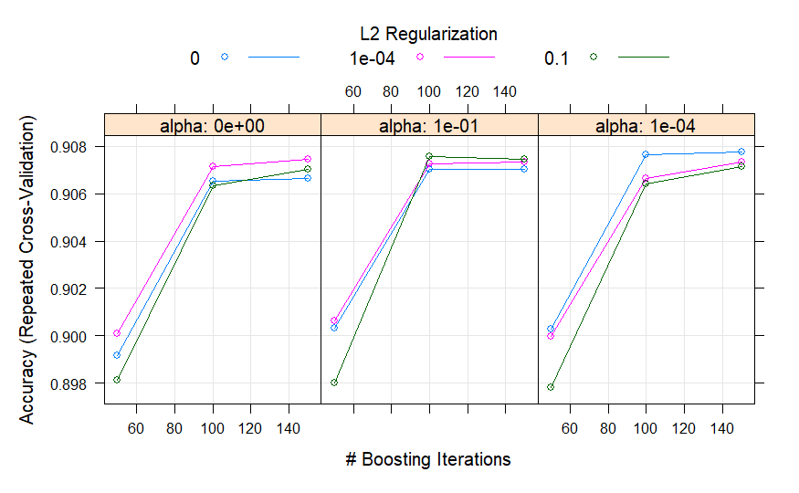

```r
plot(xgb_lin_clf)
```

Perform hyperparameter tuning using `tuneGrid`.

```r
xgb_lin_tuneGrid <- expand.grid(
  eta = 0.3,
  lambda = c(1e-04, 1e-01, 0),
  alpha = 1e-04,
  nrounds = seq(100, 200, 10)
)

xgb_lin_clf <- train_xgb("xgbLinear", tuneGrid = xgb_lin_tuneGrid)
```

```
eXtreme Gradient Boosting

964 samples
 13 predictor
  3 classes: 'Low', 'Moderate', 'High'

No pre-processing
Resampling: Cross-Validated (10 fold, repeated 10 times)
Summary of sample sizes: 868, 868, 868, 868, 867, 868, ...
Resampling results across tuning parameters:

  lambda  nrounds  Accuracy   Kappa
  0e+00   100      0.9076654  0.8351370
  0e+00   110      0.9080820  0.8358819
  0e+00   120      0.9070415  0.8340715
  0e+00   130      0.9073550  0.8346281
  0e+00   140      0.9072530  0.8344580
  0e+00   150      0.9077749  0.8353693
  0e+00   160      0.9078812  0.8355802
  0e+00   170      0.9075666  0.8350516
  0e+00   180      0.9072552  0.8344856
  0e+00   190      0.9074624  0.8348447
  0e+00   200      0.9075655  0.8350759
  1e-04   100      0.9066302  0.8333395
  1e-04   110      0.9076675  0.8352659
  1e-04   120      0.9066302  0.8333379
  1e-04   130      0.9070425  0.8340470
  1e-04   140      0.9072562  0.8344615
  1e-04   150      0.9073572  0.8346511
  1e-04   160      0.9070479  0.8341149
  1e-04   170      0.9074635  0.8348916
  1e-04   180      0.9070479  0.8341590
  1e-04   190      0.9079843  0.8357688
  1e-04   200      0.9078780  0.8355955
  1e-01   100      0.9064197  0.8329374
  1e-01   110      0.9063209  0.8327428
  1e-01   120      0.9060062  0.8322282
  1e-01   130      0.9069427  0.8339515
  1e-01   140      0.9068385  0.8337792
  1e-01   150      0.9071510  0.8343225
  1e-01   160      0.9068406  0.8337568
  1e-01   170      0.9069459  0.8339338
  1e-01   180      0.9072562  0.8344809
  1e-01   190      0.9072562  0.8344794
  1e-01   200      0.9075687  0.8350982

Tuning parameter 'alpha' was held constant at a value of 1e-04

Tuning parameter 'eta' was held constant at a value of 0.3
Accuracy was used to select the optimal model using the largest value.
The final values used for the model were nrounds = 110, lambda = 0, alpha
 = 1e-04 and eta = 0.3.
```

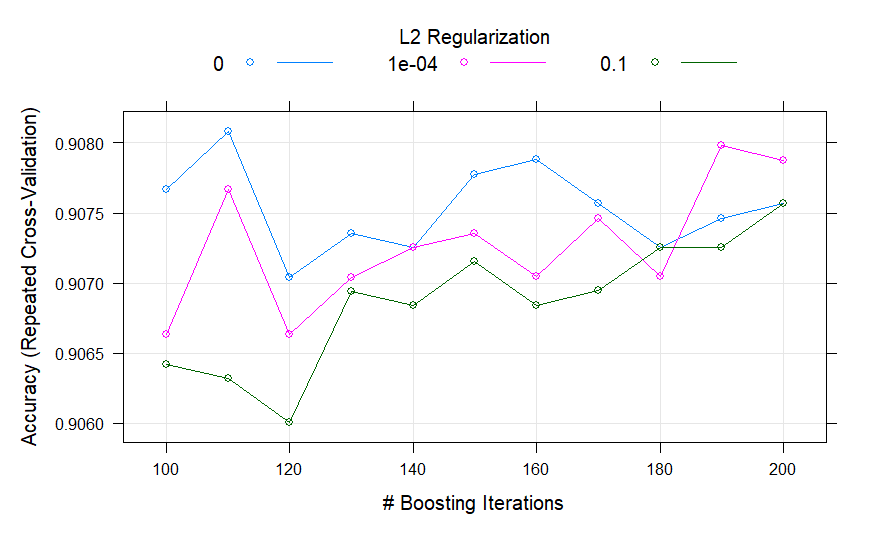

```r
plot(xgb_lin_clf)
```

Tuning done.

```r
xgb_lin_metrics <- evaluate_model(xgb_lin_clf, "XGB - Linear", family = "XGB")
```

```
Confusion Matrix and Statistics

          Reference
Prediction Low Moderate High
  Low       88        6    0
  Moderate   7      118    6
  High       1        1   14

Overall Statistics

               Accuracy : 0.9129
                 95% CI : (0.8699, 0.9453)
    No Information Rate : 0.5187
    P-Value [Acc > NIR] : <2e-16

                  Kappa : 0.8436

 Mcnemar's Test P-Value : 0.1994

Statistics by Class:

                     Class: Low Class: Moderate Class: High
Precision                0.9362          0.9008     0.87500
Recall                   0.9167          0.9440     0.70000
F1                       0.9263          0.9219     0.77778
Prevalence               0.3983          0.5187     0.08299
Detection Rate           0.3651          0.4896     0.05809
Detection Prevalence     0.3900          0.5436     0.06639
Balanced Accuracy        0.9376          0.9160     0.84548
```

##### Train Set (RFE)

```r
xgb_lin_clf_rfe <- train_xgb("xgbLinear", train_set_rfe)
```

```
eXtreme Gradient Boosting

964 samples
 12 predictor
  3 classes: 'Low', 'Moderate', 'High'

No pre-processing
Resampling: Cross-Validated (10 fold, repeated 10 times)
Summary of sample sizes: 868, 868, 868, 868, 867, 868, ...
Resampling results across tuning parameters:

  lambda  alpha  nrounds  Accuracy   Kappa
  0e+00   0e+00   50      0.8871209  0.7980597
  0e+00   0e+00  100      0.8937683  0.8104314
  0e+00   0e+00  150      0.8936641  0.8101761
  0e+00   1e-04   50      0.8878512  0.7995009
  0e+00   1e-04  100      0.8942869  0.8113283
  0e+00   1e-04  150      0.8939766  0.8107397
  0e+00   1e-01   50      0.8871263  0.7978632
  0e+00   1e-01  100      0.8950086  0.8125744
  0e+00   1e-01  150      0.8952223  0.8129498
  1e-04   0e+00   50      0.8869115  0.7976716
  1e-04   0e+00  100      0.8935610  0.8100504
  1e-04   0e+00  150      0.8935599  0.8100560
  1e-04   1e-04   50      0.8878533  0.7994456
  1e-04   1e-04  100      0.8945994  0.8118988
  1e-04   1e-04  150      0.8941806  0.8111420
  1e-04   1e-01   50      0.8870232  0.7976576
  1e-04   1e-01  100      0.8949055  0.8124092
  1e-04   1e-01  150      0.8953254  0.8131373
  1e-01   0e+00   50      0.8857807  0.7956473
  1e-01   0e+00  100      0.8931433  0.8092531
  1e-01   0e+00  150      0.8944963  0.8116914
  1e-01   1e-04   50      0.8850548  0.7942290
  1e-01   1e-04  100      0.8935621  0.8100327
  1e-01   1e-04  150      0.8941860  0.8110909
  1e-01   1e-01   50      0.8847444  0.7933213
  1e-01   1e-01  100      0.8944963  0.8116858
  1e-01   1e-01  150      0.8948088  0.8123115

Tuning parameter 'eta' was held constant at a value of 0.3
Accuracy was used to select the optimal model using the largest value.
The final values used for the model were nrounds = 150, lambda = 1e-04,
 alpha = 0.1 and eta = 0.3.
```

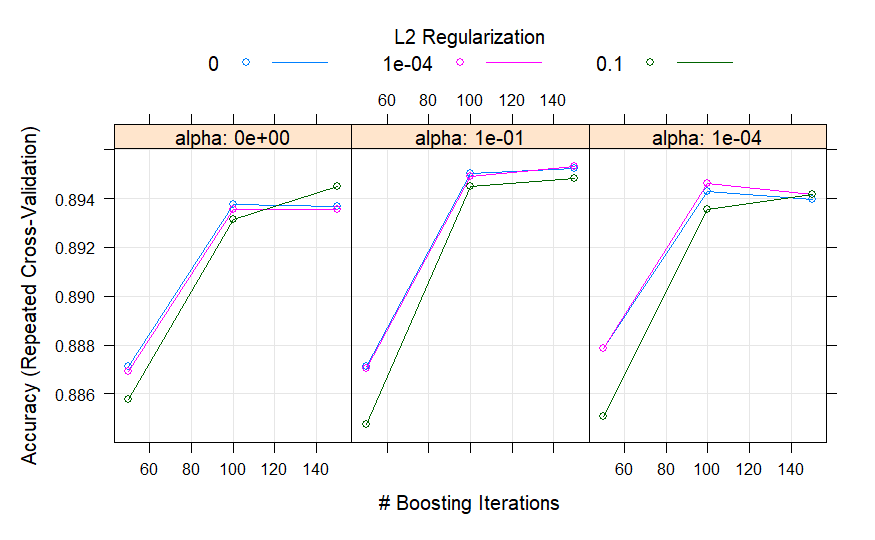

```r
plot(xgb_lin_clf_rfe)
```

Perform hyperparameter tuning using `tuneGrid`.

```r
xgb_lin_tuneGrid_rfe <- expand.grid(
  eta = 0.3,
  lambda = c(1e-04, 0),
  alpha = 1e-01,
  nrounds = seq(100, 200, 10)
)

xgb_lin_clf_rfe <- train_xgb(
  "xgbLinear",
  train_set_rfe,
  tuneGrid = xgb_lin_tuneGrid_rfe
)
```

```
eXtreme Gradient Boosting

964 samples
 12 predictor
  3 classes: 'Low', 'Moderate', 'High'

No pre-processing
Resampling: Cross-Validated (10 fold, repeated 10 times)
Summary of sample sizes: 868, 868, 868, 868, 867, 868, ...
Resampling results across tuning parameters:

  lambda  nrounds  Accuracy   Kappa
  0e+00   100      0.8950086  0.8125744
  0e+00   110      0.8944910  0.8116302
  0e+00   120      0.8954296  0.8132994
  0e+00   130      0.8955326  0.8135359
  0e+00   140      0.8955305  0.8135183
  0e+00   150      0.8952223  0.8129498
  0e+00   160      0.8950150  0.8125858
  0e+00   170      0.8948067  0.8121952
  0e+00   180      0.8948056  0.8122126
  0e+00   190      0.8945984  0.8118293
  0e+00   200      0.8943922  0.8114633
  1e-04   100      0.8949055  0.8124092
  1e-04   110      0.8946982  0.8119967
  1e-04   120      0.8952212  0.8129359
  1e-04   130      0.8954296  0.8133388
  1e-04   140      0.8953232  0.8131406
  1e-04   150      0.8953254  0.8131373
  1e-04   160      0.8951181  0.8127725
  1e-04   170      0.8948056  0.8122073
  1e-04   180      0.8950140  0.8126096
  1e-04   190      0.8945984  0.8118700
  1e-04   200      0.8944953  0.8116858

Tuning parameter 'alpha' was held constant at a value of 0.1
Tuning
 parameter 'eta' was held constant at a value of 0.3
Accuracy was used to select the optimal model using the largest value.
The final values used for the model were nrounds = 130, lambda = 0, alpha
 = 0.1 and eta = 0.3.
```

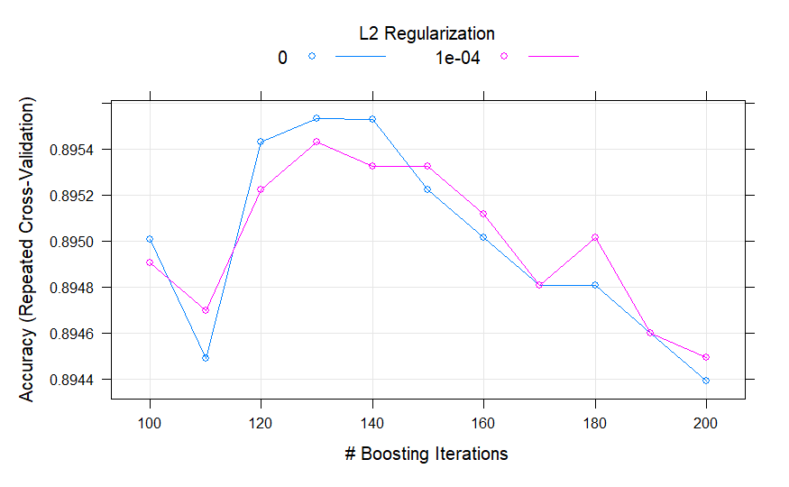

```r
plot(xgb_lin_clf_rfe)
```

Tuning done.

```r
xgb_lin_metrics_rfe <- evaluate_model(
  xgb_lin_clf_rfe,
  "XGB - Linear",
  test_set_rfe,
  "XGB"
)
```

```
Confusion Matrix and Statistics

          Reference
Prediction Low Moderate High
  Low       86       10    0
  Moderate   9      115    6
  High       1        0   14

Overall Statistics

               Accuracy : 0.8921
                 95% CI : (0.8459, 0.9283)
    No Information Rate : 0.5187
    P-Value [Acc > NIR] : < 2e-16

                  Kappa : 0.8061

 Mcnemar's Test P-Value : 0.07024

Statistics by Class:

                     Class: Low Class: Moderate Class: High
Precision                0.8958          0.8846     0.93333
Recall                   0.8958          0.9200     0.70000
F1                       0.8958          0.9020     0.80000
Prevalence               0.3983          0.5187     0.08299
Detection Rate           0.3568          0.4772     0.05809
Detection Prevalence     0.3983          0.5394     0.06224
Balanced Accuracy        0.9134          0.8953     0.84774
```

#### Support Vector Machine (Linear)

##### Train Set

```r
svm_lin_clf <- train_model("svmLinear2")
```

```
Support Vector Machines with Linear Kernel

964 samples
 13 predictor
  3 classes: 'Low', 'Moderate', 'High'

No pre-processing
Resampling: Cross-Validated (10 fold, repeated 10 times)
Summary of sample sizes: 868, 868, 868, 868, 867, 868, ...
Resampling results across tuning parameters:

  cost  Accuracy   Kappa
  0.25  0.7407678  0.5270687
  0.50  0.7424238  0.5312994
  1.00  0.7432560  0.5334430

Accuracy was used to select the optimal model using the largest value.
The final value used for the model was cost = 1.
```

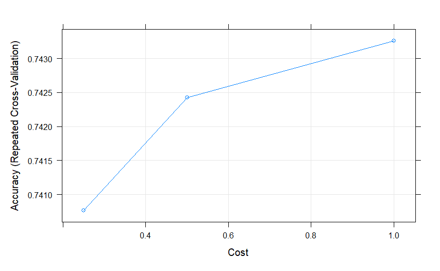

```r
plot(svm_lin_clf)
```

Perform hyperparameter tuning using `tuneGrid`.

```r
svm_lin_tuneGrid <- expand.grid(cost = seq(1, 5, 0.25))

svm_lin_clf <- train_model("svmLinear2", tuneGrid = svm_lin_tuneGrid)
```

```
Support Vector Machines with Linear Kernel

964 samples
 13 predictor
  3 classes: 'Low', 'Moderate', 'High'

No pre-processing
Resampling: Cross-Validated (10 fold, repeated 10 times)
Summary of sample sizes: 868, 868, 868, 868, 867, 868, ...
Resampling results across tuning parameters:

  cost  Accuracy   Kappa
  1.00  0.7432560  0.5334430
  1.25  0.7443997  0.5354153
  1.50  0.7430423  0.5330912
  1.75  0.7446016  0.5360775
  2.00  0.7448088  0.5365284
  2.25  0.7449098  0.5366335
  2.50  0.7450161  0.5368247
  2.75  0.7443900  0.5357920
  3.00  0.7448046  0.5365014
  3.25  0.7450129  0.5367883
  3.50  0.7446993  0.5362063
  3.75  0.7442869  0.5355115
  4.00  0.7435588  0.5339904
  4.25  0.7440786  0.5350087
  4.50  0.7444953  0.5358722
  4.75  0.7439744  0.5347404
  5.00  0.7437683  0.5344512

Accuracy was used to select the optimal model using the largest value.
The final value used for the model was cost = 2.5.
```

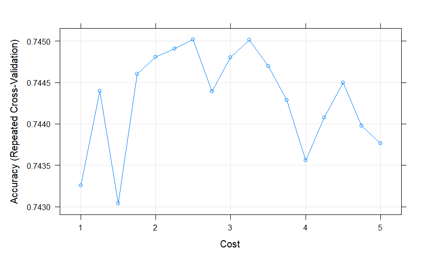

```r
plot(svm_lin_clf)
```

Tuning done.

```r
svm_lin_metrics <- evaluate_model(svm_lin_clf, "SVM - Linear", family = "SVM")
```

```
Confusion Matrix and Statistics

          Reference
Prediction Low Moderate High
  Low       75       27    3
  Moderate  21       93    9
  High       0        5    8

Overall Statistics

               Accuracy : 0.7303
                 95% CI : (0.6696, 0.7853)
    No Information Rate : 0.5187
    P-Value [Acc > NIR] : 1.491e-11

                  Kappa : 0.516

 Mcnemar's Test P-Value : 0.1798

Statistics by Class:

                     Class: Low Class: Moderate Class: High
Precision                0.7143          0.7561     0.61538
Recall                   0.7812          0.7440     0.40000
F1                       0.7463          0.7500     0.48485
Prevalence               0.3983          0.5187     0.08299
Detection Rate           0.3112          0.3859     0.03320
Detection Prevalence     0.4357          0.5104     0.05394
Balanced Accuracy        0.7872          0.7427     0.68869
```